## Assignment 9

#### Due Friday, April 14, 11:59 PM CT

### Preliminaries

- Directories
  - COURSE/homework/
  - COURSE/homework/hw09/
  - COURSE/data/
  - COURSE/scripts/
- Files
  - COURSE/homework/hw09/hw09.Rmd
  - COURSE/data/chimpanzees.csv
  - COURSE/scripts/viridis.R
  - COURSE/scripts/ggprob.R

### Data

- The data are in the file `chimpanzee.csv`.
- These data are artificial, but created to match details from a 2011 PNAS paper on chimpanzee prosocial choice.
- See the [Course Notes and Case Studies Chapter 18](https://bookdown.org/bret_larget/stat-240-case-studies/chimpanzees-and-prosocial-choice.html) for background on the data.

### Aims

- Practice inference on proportions

## Problems

1. This problem uses the chimpanzee prosocial experiment data we have been using in lecture. For this problem, we will:
- Consider only those trials with a partner.
- Make an assumption that there is a universal $p_{\text{partner}}$ representing the probability any chimpanzee would make a prosocial choice in a single trial under the experimental conditions we have been examining.
- Assume that all trials are independent.

Do the following:

- Read in the `chimpanzee.csv` data file.
- Create a summary table with:
  - one row for all trials with a partner and one row for all trials without a partner;
  - a column `prosocial` with the combined number of prosocial choices made (separate values for with and without a partner);
  - a column `selfish` for the number of selfish choices made;
  - a column `n` with the combined number of trials (values should be 610 and 180);
  - a column `p_prosocial` with the proportion of prosocial choices made.
- Print the entire table

```r
chimpanzee = read_csv("../../data/chimpanzee.csv")

table = chimpanzee %>%
  mutate(session_type = case_when(
    partner == "none" ~ "no partner",
    TRUE ~ "partner"
  ),
  n = n()) %>%
  select(prosocial, selfish, session_type, n) %>%
  group_by(session_type) %>%
  summarize(prosocial = sum(prosocial),
            selfish = sum(selfish),
            n=n()) %>%
  mutate(n = prosocial + selfish,
         p_prosocial = prosocial / n)

table
```

```
## # A tibble: 2 × 5
##   session_type prosocial selfish     n p_prosocial
##   <chr>            <dbl>   <dbl> <dbl>       <dbl>
## 1 no partner          83      97   180       0.461
## 2 partner            359     251   610       0.589
```

2. Define $p_1 = p_{\text{partner}}$ and $p_2 = p_{\text{no partner}}$ to be the long-run probabilities that chimpanzees make the prosocial choices with and without a partner, respectively, in the experimental conditions. (*You can decide which subscripts to use*.) Note that these parameter definitions implicitly assume that all trials are independent and that the identities of the chimpanzees and their partners do not affect the prosocial trial probabilities. These assumptions could and should be examined, but complete these problems as if the assumptions are accurate.
- Write a statistical model for the data, $X_1$ and $X_2$, the number of pro-social choices under the two conditions. (It may be helpful to copy and edit LaTeX syntax from the lecture notes if you want to make the knitted document look pretty, but plain text is also fine.)

> For X1: X | p ~ Binomial (610, 0.589) For X2: X | p ~ Binomial (180, 0.461)
- Use the data summary in Problem 1 to construct a 95% confidence interval for $p_{\text{partner}} - p_{\text{no partner}}$ (or $p_1 - p_2$), using the Agresti-Coffe method for confidence intervals for differences in proportions.

```r
p1 = ((table$prosocial[1]+2) / (table$n[1]+4))
p2 = ((table$prosocial[2]+2) / (table$n[2]+4))

pnopartner = p1 + 1.96 * sqrt((p1*(1-p1))/(table$n[1]+4))
ppartner = p2 + 1.96 * sqrt((p2*(1-p2))/(table$n[2]+4))

# p1 + 1.96 * sqrt((p1*(1-p1))/(table$n[1]+4)) -
#   p2 + 1.96 * sqrt((p2*(1-p2))/(table$n[2]+4))

pnopartner - ppartner
```

```
## [1] -0.09288719
```

- Interpret this confidence interval in context, following model language in lecture notes.

> H0 : p = 0.5 Ha : p != 0.5

> X | p ~ Binomial(610, 0.5)

```r
sampledis = sqrt((0.5*(1-0.5))/610)
sampledis
```

```
## [1] 0.02024441
```

> sampling distribution: 0.02024441

```r
outcome = dbinom(359, 610, 0.5)
outcome
```

```
## [1] 2.197334e-06
```

> The outcome is 2.197334e-06, which is smaller than 0.01, which means it is highly statistically significant against the null hypothesis

```r
pval = dbinom(359, 610, 0.5)

temp = tibble(
  x = 0:610,
  prob = dbinom(x, 610, 0.5),
  prob2 = prob/610) %>%
  filter(prob < pval | near(prob, pval))


tibble(
  x = 0:610,
  prob = dbinom(x, 610, 0.5)) %>%
  filter(near(prob, pval))
```

```
## # A tibble: 2 × 2
##       x       prob
##   <int>      <dbl>
## 1   251 0.00000220
## 2   359 0.00000220
```

```r
pvalr = temp %>%
  summarize(pvalue = sum(prob)) %>%
  pull(pvalue)
pvalr
```

```
## [1] 1.405895e-05
```

> The p-value is 1.405895e-05

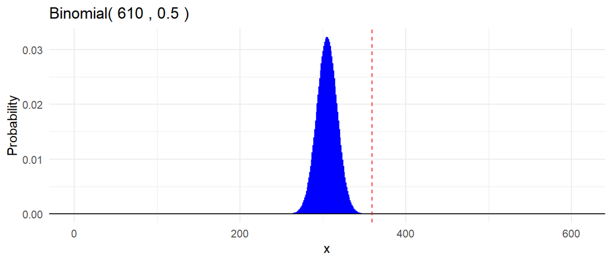

```r
gbinom(610, 0.5)+geom_vline(xintercept=359, color="red",
             linetype="dashed")
```

```r
m = table$prosocial[1]/table$n[1]
m
```

```
## [1] 0.4611111
```

```r
m2 = (table$prosocial[1]/table$n[1])/2
m2
```

```
## [1] 0.2305556
```

> H0 : p = 0.4611111 Ha : p < 0.4611111

> X ~ Binomial(180, 0.4611111)

```r
sampledis2 = sqrt((m*(1-m))/180)
sampledis2
```

```
## [1] 0.03715491
```

> sampling distribution is 0.03715491

```r
outcome2 = dbinom(83, 180, m)
outcome2
```

```
## [1] 0.05956804
```

```r
pval2 = dbinom(83, 180, m)

temp = tibble(
  x = 0:180,
  prob = dbinom(x, 180, m),
  prob2 = prob/180) %>%
  filter(prob < pval2 | near(prob, pval2))


tibble(
  x = 0:180,
  prob = dbinom(x, 180, m)) %>%
  filter(near(prob, pval2))
```

```
## # A tibble: 1 × 2
##       x   prob
##   <int>  <dbl>
## 1    83 0.0596
```

```r
pvalr2 = temp %>%
  summarize(pvalue = sum(prob)) %>%
  pull(pvalue)
pvalr2
```

```
## [1] 1
```

```r
pval3 = dbinom(83, 180, m2)

temp = tibble(
  x = 0:180,
  prob = dbinom(x, 180, m2)) %>%
  filter(prob < pval3 | near(prob, pval3))

tibble(
  x = 0:180,
  prob = dbinom(x, 180, m2)) %>%
  filter(near(prob, pval3))
```

```
## # A tibble: 120 × 2
##        x     prob
##    <int>    <dbl>
##  1     0 3.25e-21
##  2     1 1.75e-19
##  3     2 4.70e-18
##  4     3 8.36e-17
##  5     4 1.11e-15
##  6     5 1.17e-14
##  7     6 1.02e-13
##  8     7 7.61e-13
##  9     8 4.93e-12
## 10     9 2.82e-11
## # … with 110 more rows
```

```r
pvalr3 = temp %>%
  summarize(pvalue = sum(prob)) %>%
  pull(pvalue)
pvalr3
```

```
## [1] 3.746207e-08
```

State one criticism where reality may differ from the assumptions, possibly leading to misleading conclusions. (What is an example of an assumption of the binomial model which, in the given context, is questionable?)

> Biased sample. For my alternative hypothesis, I chose a value less than the calculated one above, which affects the conclusion of our binomial model. it is biased because I chose the probability.
7. In a poll from the 2022 election for governor in Wisconsin, 326 out of 679 likely voters responded that they would vote for the incumbent Tony Evers. Using the Agresti-Coull method, find a 95% confidence interval for the proportion of likely voters in Wisconsin who voted vote for Tony Evers in the November 8 election.

```r
x3=326
n3=679
p3 = (x3+20)/(n3+4)

pplus = p3 + 1.96 * sqrt((p3*(1-p3))/(n3+4))
pplus
```

```
## [1] 0.544084
```

```r
mminus = p3 - 1.96 * sqrt((p3*(1-p3))/(n3+4))
mminus
```

```
## [1] 0.4690932
```

Interpret the confidence interval in context.

In guesses of the suits of 100 cards, the psychic correctly guesses the suit 29 times. Conduct a formal hypothesis test to examine the evidence that the psychic can guess the suit of the cards more often than expected. State a model, declare a test statistic, state hypotheses, calculate a one-sided p-value, and report the results in the context of the problem following the format presented in lecture notes.

> Model : X | p ~ Binomial (100, 0.29)

> Test Statistic : X | p ~ Binomial (100, 0.2)

> Ha: p = 0.2 Ho: p > 0.2

```r
p.4null = dbinom(28, 100, 0.2)
p.4null
```

```
## [1] 0.01413142
```

```r
p.4alt = dbinom(28, 100, 0.3)
p.4alt
```

```
## [1] 0.08041202
```

> pval is 0.01413142 or 0.08041202